# Strategic Formal Layoffs: Unemployment Insurance and Informal Labor Markets

Converted from PDF `VanDoornik-StrategicFormalLayoffs-2023-AEJAE.pdf` · 28 pages · anchors: page `#pN`, block `#pN-bK`

Page 1

*American Economic Journal: Applied Economics 2023, 15(1): 292–318 https://doi.org/10.1257/app.20200787*

*292*

### Strategic Formal Layoffs: Unemployment Insurance

### and Informal Labor Markets†

*By* Bernardus Van Doornik, David Schoenherr, and Janis Skrastins*

*Exploiting an unemployment insurance reform in Brazil*, *we study incentive effects of UI in the presence of informal labor markets. We find that eligibility for UI benefits increases formal layoffs by 11 percent. Most of the additional layoffs are related to workers transitioning to informal employment. We further document formal layoff and recall patterns consistent with rent extraction from the UI system. Workers are laid off as they become eligible for UI benefits and recalled when benefits cease. These patterns are stronger for industries and municipalities with a high degree of labor market informality.* (*JEL* J22, J46, J63, J65, K31, O15)

## **E**

xperiencing shocks to labor income is one of the most salient risks faced by households (Rothstein and Valletta 2017). To allay adverse effects of job loss on household income, government-mandated unemployment insurance (UI) programs have been in place in developed countries for decades. However, adverse labor supply effects of UI generate a trade-off between providing insurance against income shocks and distorting labor supply.<sup>1</sup>

More recently, the implementation of government-mandated UI programs has been spreading to an increasing number of mid-income and developing countries

1 E.g., Solon (1979); Moffitt (1985); Katz and Meyer (1990a); Meyer (1990, 1995); Card and Levine (2000); Meyer and Mok (2007); Card, Johnston et al. (2015); Farber, Rothstein, and Valletta (2015); Johnston and Mas (2018); and Landais (2015) for the United States, and Card, Chetty and Weber (2007); Lalive (2008); Schmieder, von Wachter, and Bender (2012, 2016); and Card, Lee et al. (2015) for western Europe.

* Van Doornik: Bank of International Settlements and Banco Central do Brasil (email: bernardus.doornik@bcb. gov.br); Schoenherr: Princeton University (email: schoenherr@princeton.edu); Skrastins: Washington University in St. Louis (email: jskrastins@wustl.edu). Camille Landais was coeditor for this article. The views expressed in the paper are those of the authors and should not be cited to reflect the view of the Banco Central do Brasil. We thank Orley Ashenfelter, Michael Best, Will Dobbie, Henry Faber, Maryam Farboodi, Dimas Fazio, Gustavo Gonzaga, Simon Jaeger, Gregor Jarosch, Ilyana Kuziemko, Mina Lee, Alexandre Mas, David Matsa, Jean-Marie Meier, Atif Mian, Jesse Rothstein, Raffaele Saggio, Andrew Samwick, Bernardo Silveira, Jan Starmans, Adam Szeidl, Motohiro Yogo, and seminar participants at the Banco Central do Brasil, the Bank of Latvia, Central European University, the Chilean Banking Authority, IPEA Brazil, Northwestern University, Princeton University, Pontifical Catholic University of Rio de Janeiro, Stockholm School of Economics in Riga, Syracuse University, the University of Chile, Washington University in St. Louis, the 2017 BCB Annual Inflation Targeting Seminar, the 2017 Asian, European, Latin American, and North American Meetings of the Econometric Society, the 2017 Boulder Summer Conference, the 2018 Meeting of the Econometric Society, the 2017 German Economists Abroad Meeting, the 2017 Fall Meeting of the Labor and Finance Group, the 2019 NBER Insurance Group Meeting, the 2018 NBER Summer Institute Labor Studies and Public Economics Meetings, the 2017 Northeastern Finance Conference, and the 2017 Annual Conference of the SOLE for their many helpful comments and suggestions. Karine Paiva provided excellent research assistance.

† Go to https://doi.org/10.1257/app.20200787 to visit the article page for additional materials and author disclosure statement(s) or to comment in the online discussion forum.

Page 2

*VOL. 15 NO. 1 293 VAN DOORNIK ET AL.: STRATEGIC FORMAL LAYOFFS*

(Holzmann et al. 2011; ILO 2017), for which we understand little about how their specific labor market characteristics interact with incentive effects of UI. A prominent feature of labor markets in mid-income and developing countries is a high degree of informality, which may interact with UI in unique ways. For example, informal labor markets provide workers with the opportunity to receive UI benefits while being employed informally.

To shed more light on the incentive effects of UI in the presence of large informal labor markets, we exploit a UI reform in Brazil that had a discontinuous effect depending on workers’ tenure. As a heterogeneous mid-income country with ample variation in labor market informality, Brazil constitutes an ideal setting for our analysis. We find that eligibility for UI benefits increases formal layoffs by 11.11 percent. Most of the additional formal layoffs are related to workers flowing into informal employment. These patterns occur primarily in industries and municipalities with a high degree of labor market informality.

The UI reform was unexpectedly announced on December 29, 2014 and implemented on March 1, 2015. Prior to the reform, all workers with tenure of six months are eligible for UI benefits. After the reform, workers applying for benefits for the first (second) time require 18 (12) months of formal employment during the previous 24 (16) months to be eligible for benefits. Thus, a subset of workers with tenure between 6 and 18 (12) months loses eligibility for UI benefits after the reform. The design of the reform motivates our main identification strategy: a difference-in-difference methodology, in which we compare changes in employment and unemployment patterns around the reform for workers above and below the six-month threshold. The fact that workers with two or more prior UI benefits spells are unaffected by the reform allows us to augment our estimation to a triple-difference methodology, comparing workers around the six-month threshold who are affected by the reform to workers around the threshold who are unaffected by the reform. This rules out confounding factors that could differentially affect workers around the threshold, for example, macroeconomic shocks, seasonal effects, or changes in incentives for workers below the threshold.

We start our analysis by examining how eligibility for UI benefits affects layoff rates. Throughout the paper we define layoffs as formal layoffs upon which workers become unemployed or work informally. We find that layoffs drop by 0.43 percentage points (11.11 percent) for affected workers above the 6-month threshold, who lose eligibility for UI benefits after the reform, compared with workers below the 6-month threshold, who were never eligible for UI benefits, relative to the same difference for unaffected workers.<sup>2</sup> Based on a difference-in-bunching estimation, we further find that layoff rates of workers below the six-month threshold are unaffected by the reform. This suggests that the additional layoffs above the threshold constitute additional layoffs due to eligibility for UI benefits rather than simply a change in layoff timing. The results are virtually unaffected by controlling for age-month and education-month fixed effects and for a reduced sample of workers with tenure of four to seven months in the four months around the reform. Moreover, the results are unaffected by including expired temporary contracts in the definition of layoffs.

2 Carvalho, Corbi, and Narita (2018) document similar patterns for an extended period around the reform.

Page 3

*294 AMERICAN ECONOMIC JOURNAL: APPLIED ECONOMICS JANUARY 2023*

Informal labor markets provide a unique alternative to formal employment in the light of UI. Workers can receive benefits while being employed informally. We find that higher layoff rates for workers eligible for UI benefits correlate with labor market informality. A 10 percentage point higher share of informal employment in a given industry or municipality is associated with an about 0.1 percentage points (2.6 percent) higher layoff rate for workers eligible for UI benefits. The link between higher layoff rates and informal labor markets is corroborated by survey evidence showing that higher layoff rates of workers eligible for UI benefits are mostly related to workers transitioning from formal to informal employment. When workers with more than six months’ tenure lose eligibility for UI benefits after the reform, they become less likely to transition to informal employment upon formal layoff. Our results suggest that 94 percent of the additional layoffs due to eligibility for UI benefits are related to formal-to-informal employment transitions (see Section IIB for details).

Higher layoff rates may be driven by various mechanisms. Workers may be more likely to shirk when their outside option is to receive UI benefits. Firms facing labor demand fluctuations may (temporarily) lay off workers who qualify for UI benefits since they are less likely to search for alternative employment (Katz 1986; Jurajda 2002). Alternatively, firms and workers may time formal unemployment spells to coincide with eligibility for UI benefits, to extract rents from the UI system (Feldstein 1976; Baily 1977), either through direct collusion, or firms may establish a reputation for laying off workers when they are eligible for UI benefits to signal their intentions in a more subtle way (Christofides and McKenna 1996).

We provide evidence consistent with firm-worker coordination to extract rents from the UI system explaining at least part of the additional layoffs. Specifically, we show that layoffs and recalls are timed to coincide with eligibility for UI benefits. Workers who are laid off as they become eligible for UI benefits are more likely to be recalled by their previous employer after they exhaust their UI benefits. While workers’ incentives to shirk are also stronger when they are eligible for UI benefits, it is hard to argue that firms are more likely to recall shirking workers.

On examining changes in salaries around the reform, we find that salaries increase 0.80 percent more for workers affected by the reform. Within the group of affected workers, salaries increase 0.30 percent more for workers who were previously laid off just as they qualified for UI benefits. This suggests that workers who engage in strategic timing of unemployment spells to coincide with eligibility for UI benefits before the reform accept lower equilibrium salaries, consistent with workers passing on rents extracted from the UI system to firms through lower salaries (see Section IIC for details).

The main contribution of our paper is to shed light on incentive effects of UI in the presence of informal labor markets. Our findings suggest that UI leads to higher layoff

Page 4

*VOL. 15 NO. 1 295 VAN DOORNIK ET AL.: STRATEGIC FORMAL LAYOFFS*

rates in the presence of informal labor markets mostly due to transitions to informal employment. We estimate that about 11 percent of UI payments for workers laid off with a tenure of 6 to 17 months are paid to strategically unemployed workers, whose layoffs are determined by their eligibility for UI benefits rather than demand shocks.

Evidence on the interaction of UI and labor market informality is scant. The closest paper to ours is Gerard and Gonzaga (2021), who examine the effects of UI on formal reemployment rates for varying levels of labor market informality by exploiting variation in UI benefits duration. They find that the marginal effect of an additional month of benefits duration on search intensities is weak, leading them to conclude that efficiency costs of social programs are lower for more informal labor markets. Our finding that UI has a stronger effect on layoff rates in the presence of informal labor markets implies that policies to limit moral hazard at the layoff margin, such as experience rating, are required for the conclusion in Gerard and Gonzaga (2021) to hold.<sup>3</sup>

Our results also relate to the literature on layoffs more broadly. Most evidence on higher employment outflow for workers eligible for UI benefits is from Canada, where individuals who quit their job can qualify for UI benefits (Christofides and McKenna 1995, 1996; Green and Riddell 1997; Baker and Rea 1998; Green and Sargent 1998). Existing studies provide mixed insights regarding the effects of different aspects of UI design on layoff rates. Anderson and Meyer (1997b) find that benefit levels but not duration impact UI take-up. Winter-Ebmer (2003) documents that layoffs are higher when benefits duration is extended. Jurajda (2002) finds that higher benefits levels have no effect on layoff rates. Recent studies from Austria and Germany find no or weak evidence of layoff timing with respect to UI eligibility (Card, Chetty, and Weber 2007; Schmieder, von Wachter, and Bender 2012). This is consistent with our findings that informal labor markets play an important role in generating higher layoff rates for workers eligible for UI benefits. Our cross-sectional estimates imply that for levels of labor market informality observed in Austria and Germany (1.4–2.9 percent (European Social Survey 2014)), less than 3 percent of layoffs occur as a consequence of workers’ eligibility for UI benefits. Nevertheless, our findings may be relevant for sectors with high levels of informality even in developed countries.

Finally, our results relate to the literature on temporary layoffs and recalls. Temporary layoffs account for a high fraction of employment outflow (Feldstein 1978; Katz and Meyer 1990b), with high recall rates for laid off workers (Nekoei and Weber 2015; Fujita and Moscarini 2017), in particular with imperfect experience rating (Feldstein 1978; Topel 1983, 1985; Anderson and Meyer 1994; Card and Levine 1994). We complement these studies by showing that firms and workers extract rents from the UI system through temporary layoffs when workers can be employed informally. This makes temporary layoffs an important concern in designing UI systems in the presence of large informal labor markets.

3 Other recent studies that analyze UI programs in middle-income and developing countries (Gasparini, Haimovich, and Olivieri 2009; González-Rozada, Ronconi, and Ruffo 2011; Amarante, Arim, and Dean 2013) do not directly examine how incentive effects of UI interact with informal labor markets.

Page 5

*296 AMERICAN ECONOMIC JOURNAL: APPLIED ECONOMICS JANUARY 2023*

#### **I. Institutional Background and Data**

This section provides information about Brazil’s UI system, the UI reform, and the data used for the empirical analysis in the paper.

A. *Unemployment Insurance in Brazil*

In Brazil every formal worker holds a working card, which employers are required to sign whenever a worker is hired, promoted, or dismissed. This information is reported to the Ministry of Economics every year. Formal employees are entitled to a minimum wage. Payroll taxes amount to 20 percent of the formal wage to finance the public pension system, plus 8.5 percent for the worker’s seniority account (FGTS). All formal employees in the private sector participate in the UI system. Funding for the UI system comes from the social integration program (PIS), mainly financed through a 0.65 percent tax on annual firm sales.

To be eligible for UI benefits, workers cannot simply quit but need to be laid off by their employer. UI benefits are paid for three to five months, depending on the worker’s time in formal employment. Three payments are made if a worker was employed for between 6 and 11 months in the last 36 months, 4 payments are made if a worker was employed for between 12 and 23 months in the last 36 months, and 5 payments are made if a worker was employed for at least 24 months in the last 36 months. In 2015 the monthly payment ranges from 1 to 1.76 minimum salaries, depending on the average pre-layoff salary. The UI system does not feature a direct experience-rating mechanism. If a firm lays off a worker, it must pay an additional 50 percent of the total contribution that has accumulated in the employee’s FGTS. This cost of laying off a worker amounts to 8–19 percent of the expected benefits payments to the worker, depending on the pre-layoff salary. Eighty percent of the penalty is directly paid to the worker, and 20 percent goes toward funding the UI system. Thus, implied experience rating, after accounting for payments that remain within the firm-worker relationship, is about 1.6–3.8 percent of the UI benefits paid to the worker through the UI system. Firing workers requires a valid legal justification, such as absence from work, negligence, or other proven misconduct. Firing does not lead to penalties, and fired workers do not qualify for UI. However, firings are rare (3.5 percent of all dismissals) since the burden of providing evidence is high and judges tend to rule in favor of employees.

B. *Unemployment Insurance Reform*

To be eligible for UI benefits prior to March 1, 2015, a worker had to be employed over a consecutive period of at least 6 months prior to layoff, not be earning other labor income, and not have successfully applied for UI benefits during the previous 16 months. On December 29, 2014 the parliament announced a provisional measure that tightened eligibility criteria for UI benefits.<sup>4</sup> This provisional measure was formally enacted the next day. The new criteria were set to be enforced from

4 We provide a detailed summary of the parts of the law governing eligibility criteria before and after the reform in online Appendix B.

Page 6

*VOL. 15 NO. 1 297 VAN DOORNIK ET AL.: STRATEGIC FORMAL LAYOFFS*

March 1, 2015. Both the sudden implementation and the content of the new law were unexpected.<sup>5</sup> The main reason for the quick implementation was attempts on the government’s part to reduce the growing budget deficit. The size and duration of UI benefits were not altered, and employers’ UI contributions were unaffected. Thus, the reform had no direct effect on employers’ demand for formal labor.

C. *Data*

We use data from RAIS (Relação Anual de Informações Sociais), a large restricted-access matched employee-employer administrative dataset from Brazil. The RAIS database records information on all formally employed workers in a given year and is maintained by the Ministry of Economics (Ministério da Economia 2014–2016). All formally registered firms in Brazil are legally required to report annual information on each worker that the firm employs. RAIS includes detailed information on the employer (tax number, sector of activity, establishment size, geographical location), the employee (social security number, age, gender, education), and the employment relationship (salary, tenure, type of employment, hiring date, layoff date, etc.). We use data from RAIS for the 2013–2016 period. By the end of 2014, the database covers about 50 million formal employees. We exclude all public sector employees since they do not participate in the UI program.

We combine data from RAIS with information on the number of previous unemployment spells maintained by the Ministry of Labor (Ministério do Trabalho 2016). This information is crucial, as the reform only applies to workers with fewer than two past UI benefits spells. In addition, we use information on the location of firms (municipality), firms’ two-digit industry classification (National Classification of Economic Activities), and information on workers’ occupations (Classificação Brasileira de Ocupações).<sup>7</sup>

We also use data from the monthly employment survey Pesquia Mensal de Emprego (PME) (IBGE 2016).<sup>8</sup> The survey interviews 44,189 individuals in

5 Estadao Politica, December 29, 2014, “Força Sindical nega ter sido consultada sobre ajuste em benefícios.” Doornik et al. (2020) show that firms whose workers benefit more from a more generous UI system experience a greater drop in their stock price following the announcement on December 29.

6 The adjusted requirements from July 2015 required a first-time applicant to have at least 12 months of employment in the last 18 months. A second-time applicant had to have at least 9 months of employment in the last 12 months.

7 We also use official inflation data (IBGE 2021), industry classifications (IBGE 2020), and firm and population registries (Receita Federal do Brasil 2021b, a). We also create a table that matches census industry classifications with two-digit CNAE classification (Doornik, Schoenherr, and Skrastins 2022).

8 We are thankful to Data Zoom, developed by the Department of Economics at PUC-Rio, for providing the codes for accessing IBGE microdata.

Page 7

*298 AMERICAN ECONOMIC JOURNAL: APPLIED ECONOMICS JANUARY 2023*

6 metropolitan areas (Recife, Salvador, Belo Horizonte, Rio de Janeiro, São Paulo, and Porto Alegre). Households are interviewed over two separate four-month periods that are eight months apart. The main advantage of the PME is that based on an algorithm developed in Ribas and Soares (2008), individuals can be assigned a unique identifier, giving the survey a panel structure. The survey provides information on whether a worker is formally employed, informally employed, or unemployed.

#### **II. Empirical Analysis**

This section describes our empirical analysis. Our empirical design exploits two sources of variation. First, we exploit that a discontinuity in eligibility for UI benefits at six months’ tenure is eliminated by the UI reform. The postreform period provides us with a counterfactual for when workers above and below six months’ tenure are ineligible for UI benefits. Second, the reform does not apply to workers with at least two previous UI benefits spells. This provides a counterfactual of workers for whom eligibility rules do not change around the reform, which we can exploit in a triple-difference estimation.

Figure 1. UI Eligibility around the Reform

*Notes:* This figure shows eligibility criteria for UI benefits before and after the reform based on workers’ tenure for workers who apply for UI benefits for the first time, the second time, or the third time or more. Red bars indicate tenure not satisfying eligibility criteria; green bars indicate tenure satisfying eligibility criteria.

0 1 2 3 4 5 6 7 8 9 10 11 12 13 14 15 16 17 18 19

Mar.–Apr. Jan.–Feb.

First:

Mar.–Apr. Jan.–Feb.

Second:

Mar.–Apr. Jan.–Feb.

More:

Tenure

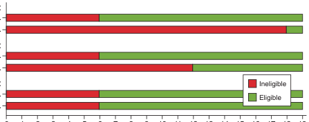

NOTE: figure/graphic rendered as an image from the PDF; its content is not machine-readable text. Caption (if any) follows as the next block.

**text found inside the figure**

Ineligible

Eligible

Page 8

*VOL. 15 NO. 1 299 VAN DOORNIK ET AL.: STRATEGIC FORMAL LAYOFFS*

Table 1—Informality by Industry

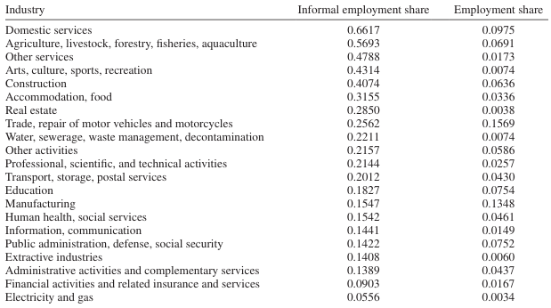

NOTE: complex table shown as an image of the PDF; the text below is a rough machine extraction and may be mis-aligned.

**extracted text (unreliable layout)**

*Note:* This table lists the informal employment share for a given industry and the share of workers employed in the respective industry based on the 2010 census.

Figure 2. Labor Market Informality by Municipality

*Note:* This figure depicts informal labor market shares for all municipalities in Brazil based on the 2010 census.

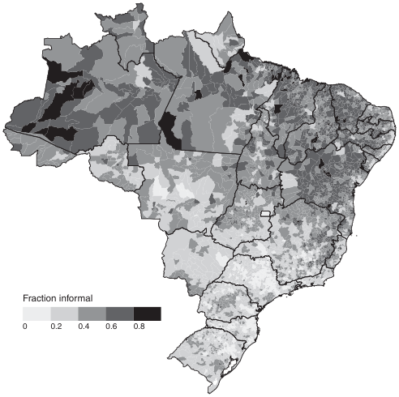

NOTE: figure/graphic rendered as an image from the PDF; its content is not machine-readable text. Caption (if any) follows as the next block.

**text found inside the figure**

Fraction informal

0 0.2 0.4 0.6 0.8

Page 9

*300 AMERICAN ECONOMIC JOURNAL: APPLIED ECONOMICS JANUARY 2023*

A. *Descriptive Statistics*

For our main analysis, we focus on workers with consecutive formal employment up to 11 months in the 2 years around the UI reform (March 2014 to February 2016). Observable characteristics in Table 2 suggest that workers with tenure above and below six months are of similar age, earn a similar salary, have a similar share of male and university-educated individuals, and work for similarly sized firms and in similar industries.

B. *Layoffs*

*Difference-in-Difference Estimation*.—We start our analysis by examining layoff patterns around the reform in Figure 3. For each tenure level, we generate a difference-in-difference estimate. Specifically, we estimate

(1) *Layof**f**it* = α*t*′ + α*aff*,*cal* + δ × *Affecte**d**i* × *Refor**m**t* + ϵ*it*,

where *Layof**f**it* is a dummy variable that takes the value of one if worker *i* is laid off in month *t* and zero otherwise. *Affecte**d**i* takes the value of one for workers with zero or one prior UI benefits spell at the time of the reform and zero otherwise. The dummy variable *Refor**m**t* takes the value of zero from March 2014 to February 2015 and one from March 2015 to February 2016. The estimation controls for municipality-industry-occupation-month fixed effects (α*t*′) to absorb shocks at the local industry-occupation level and affected–calendar month fixed effects (α*aff*,*cal*) to control for seasonal patterns in layoff rates for affected and unaffected workers.

For the tenure ranges from 6 to 11 months and 12 to 17 months, we observe a drop in layoff rates for affected workers by 0.4 and 0.3 percentage points, respectively, when they lose eligibility for UI benefits after the reform. For workers below the six-month threshold, we do not observe systematic changes in layoff rates. Affected workers’ postreform layoff rates are marginally lower for some tenures beyond 17 months. One explanation for lower layoff rates beyond 17 months is that requalifying for UI benefits becomes harder for affected workers after the reform, which increases their incentive to remain in their current job.

To ensure that the patterns in Figure 3 are not driven by different time trends for affected and unaffected workers, in Figure 4 we estimate the difference in layoff rates for workers with 6 to 11 months’ tenure compared to workers with 0 to 5 months’ tenure for affected relative to unaffected workers each month. Specifically, we estimate

(2) *Layof**f**it* = α*t*′ + α6*m*,*t* + α*ten*,*cal* + β1 × *Affecte**d**i* + β2 × 6*Month**s**it*

× *Affecte**d**i* +  ∑ *s*=−12,*s*≠−1

12 ι*s* × *Mont**h**s* × 6*Month**s**it* × *Affecte**d**i* + ϵ*it*,

where the dummy variable 6*Month**s**it* takes the value of 1 for workers with tenure of 6 to 11 months and 0 for workers with tenure of 0 to 5 months. The dummy variables *Mont**h**s* take the value of one *s* months after the implementation of the reform in March 2015 and zero otherwise. Eligibility-month fixed effects (α6*m*,*t*)

Page 10

*VOL. 15 NO. 1 301 VAN DOORNIK ET AL.: STRATEGIC FORMAL LAYOFFS*

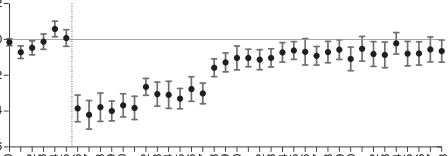

NOTE: figure/graphic rendered as an image from the PDF; its content is not machine-readable text. Caption (if any) follows as the next block.

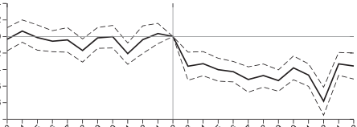

NOTE: figure/graphic rendered as an image from the PDF; its content is not machine-readable text. Caption (if any) follows as the next block.

control for differences in layoff rates for workers on either side of the threshold that are unrelated to the reform, and tenure–calendar month fixed effects

Table 2—Summary Statistics for Workers around the Threshold

[output not shown]

NOTE: table converted from PDF layout to HTML text; cell boundaries are reconstructed. See PDF if exact alignment matters.

*Notes:* This table reports pre-reform descriptive statistics for workers with tenure of 0 to 5 months in the first column and workers with tenure of 6 to 11 months in the second column. The third column depicts the difference.

Figure 3. Formal Layoffs by Tenure

*Notes:* This figure estimates changes in layoff rates for affected and unaffected workers around the reform (March 2015 to February 2016 relative to March 2014 to February 2015) for each tenure from 0 to 38 months with occupation-municipality-industry-month and affected–calendar month fixed effects. The vertical bars represent 99 percent confidence intervals.

0 1 2 3 4 5 6 7 8 9 10 11 12 13 14 15 16 17 18 19 20 21 22 23 24 25 26 27 28 29 30 31 32 33 34 35 36 37 38

−0.006

−0.004

−0.002

0

0.002

Workers’ tenure

layoff rate

Figure 4. Formal Layoffs—Dynamics

*Notes:* This figure depicts the results from estimating equation (2) comparing layoff rates for workers with 6 to 11 months’ tenure relative to workers with up to 5 months’ tenure for affected compared to unaffected workers for every month from March 2014 to February 2016, normalized to zero in February 2015. The dashed lines represent 99 percent confidence intervals.

2014:3 2014:4 2014:5 2014:6 2014:7 2014:8 2014:9 2014:10 2014:11 2014:12 2015:1 2015:2 2015:3 2015:4 2015:5 2015:6 2015:7 2015:8 2015:9 2015:10 2015:11 2015:12 2016:1 2016:2

−0.01

−0.008

−0.006

−0.004

−0.002

0

0.002

0.004

Layoff rate

Page 11

*302 AMERICAN ECONOMIC JOURNAL: APPLIED ECONOMICS JANUARY 2023*

(α*ten*,*cal*) control for tenure-specific seasonal patterns in layoff rates. All other variables are defined as above.

We observe parallel trends before the reform. In contrast, after the reform layoff rates for affected workers with tenure of 6 to 11 months drop sharply and remain consistently lower. Together, this suggests that changes in layoff rates for affected workers with 6 to 11 months’ tenure are driven by the reform rather than different time trends.

We complement the insights from the graphical analysis by estimating equation (2) replacing individual *Mont**h**s* dummies with the *Refor**m**t* dummy from equation (1). The results are gathered in Table 3. We find that layoff rates for affected workers above the 6-month threshold drop by 0.43 percentage points (11.11 percent) when they lose eligibility for UI benefits after the reform (column 1). In columns 2 and 3, we replace month-municipality-industry-occupation fixed effects with month-municipality and month-municipality-industry fixed effects, respectively, which does not affect the results. In column 4 we add age-month and education-month fixed effects and find similar results. In column 5 we limit the sample to workers with four to seven months’ tenure in the four months around the reform. This ensures that the results are not affected by affected workers selecting into jobs with longer expected tenure after the reform (Green and Riddell 1997). In column 6 we expand the sample to include workers with 0 to 17 months’ tenure and observe similar results with smaller magnitudes, which reflects the fact that workers with 1 prior UI spell do not lose eligibility for UI benefits between 12 to 17 months. In column 7 we include expired temporary contracts in the definition of layoffs, which does not affect the results. Finally, in column 8 we show that the results are not driven by a relabeling of layoffs as other forms of separations such as quits and firings, which behave similarly around the reform.

*Difference-in-Bunching Estimation*.—One concern with the estimation strategy in equation (2) is that changes in eligibility rules for the tenure range above 6 months may have dynamic effects on layoff incentives for shorter tenures. For example, layoffs at shorter tenures may be delayed when eligibility for UI benefits can be achieved with a shorter period of continued employment. This would lead to missing mass in layoff rates below the six-month threshold before the reform (Khoury 2021) and therefore bias our estimates. While the evidence in Figure 3 suggests that layoff rates below the six-month tenure threshold are not systematically affected by the reform, a more direct methodology to assess the presence of dynamic incentive effects below the eligibility threshold is a bunching design (Chetty et al. 2011; Kleven and Waseem 2013). We provide a detailed description of the implementation of the bunching estimation in online Appendix C.

Figure 5 provides the observed and counterfactual layoff distributions. The counterfactual distribution is based on the postreform layoff patterns when the eligibility threshold is at 12 or 18 months for workers with 1 or 0 prior UI benefits spells, respectively. In addition, the counterfactual distribution adjusts for differences in layoffs around the reform for unaffected workers to account for general time series changes in layoffs. We find that the observed distribution is almost identical to the counterfactual distribution for the tenure range from zero to five months. This suggests that layoff intensities below the six-month threshold are not affected by their adjacency to

Page 12

*VOL. 15 NO. 1 303 VAN DOORNIK ET AL.: STRATEGIC FORMAL LAYOFFS*

the eligibility threshold. This further implies that the excess layoffs we observe when workers are eligible for UI benefits with six months’ tenure are additional layoffs that do not occur in the absence of UI benefits, rather than a shift in layoff timing.

We complement the graphical evidence in Figure 5 with estimates of excess layoffs (*B* <sup>ˆ</sup> ) in the tenure range from 6 to 11 or 6 to 17 months and the missing mass (*M* ˆ  ) below the threshold in Table 4. The estimates are scaled by the number of affected workers with tenure range from 6 to 11 or 6 to 17 months before the reform (*N* 6+ *pre* ). Consistent with the graphical evidence, we find that layoff rates are 0.62 percentage points higher for affected workers with tenure from 6 to 11 months when they qualify for UI benefits (column 1). The estimate is similar with 0.59 percentage points for the tenure range from 6 to 17 months (column 2). The slightly higher magnitudes compared to the triple-difference methodology in Table 3 are mainly due to more stringent fixed effects in the triple-difference estimation. In contrast, layoff rates below the six-month threshold are not affected by changes in the eligibility threshold. If anything, we observe marginally higher layoff rates (i.e., the

Table 3—Formal Layoffs

[output not shown]

NOTE: table converted from PDF layout to HTML text; cell boundaries are reconstructed. See PDF if exact alignment matters.

*Notes:* The dependent variable *Layof**f**it* is a dummy variable that takes the value of one if worker *i* is formally laid off in month *t* and zero otherwise. In column 7 it also takes the value of one for expired temporary contracts. In column 8 the dependent variable *Qui**t**it* is a dummy variable that takes the value of one if worker *i* separates from their employer, but is not laid off, in month *t* and zero otherwise. The dummy variable 6*Month**s**it* takes the value of 1 for workers with tenure of 6 to 11 months (6 to 7 months and 6 to 17 in columns 5 and 6, respectively) and 0 for workers with tenure up to 5 months (4 to 5 months in column 5). The dummy variable *Refor**m**t* takes the value of one for the postreform period from March 2015 to February 2016 and zero for the pre-reform period from March 2014 to February 2015 (March to April 2015 and January to February 2015 in column 5). The dummy variable *Affecte**d**i* takes the value of one for workers with zero or one prior UI benefits spell and zero for workers with two or more prior UI benefits spells. Due to computational constraints, the estimates are based on a 10 percent random sample. Standard errors are reported in parentheses. The bottom part of the table reports information on fixed effects and the clustering of standard errors.

Page 13

*304 AMERICAN ECONOMIC JOURNAL: APPLIED ECONOMICS JANUARY 2023*

missing mass is negative) for zero to five months’ tenure before the reform when all workers with tenure of six months are eligible for UI benefits. This implies that the additional layoffs when workers qualify for UI benefits are generated at the extensive margin, i.e., constitute additional layoffs rather than a shift in layoff timing.

*Labor Market Informality*.—Next, we examine the role of informal labor markets in explaining the layoff patterns we observe. Informal labor markets are unique in enabling workers to receive UI benefits while being (informally) employed. We exploit two sources of variation in labor market informality: cross-sectional variation in informality across industries and municipalities.

To formally assess how strategic formal layoff rates interact with informal labor markets, we add a continuous variable *Informal*, the share of informal employment in a given industry or municipality, and its interaction with the other independent variables in equation (2). The results are displayed in Table 5, columns 1 and 2. We find that a 10 percentage point increase in labor market informality at the industry level leads to a 0.13 percentage point greater decrease in layoff rates for affected workers with tenure of 6 to 11 months when they lose eligibility for UI benefits after the reform (column 1). The effect is similar with a 0.09 percentage point greater decrease per 10 percentage point increase in labor market informality at the municipality level (column 2).

Figure 5. Formal Layoffs by Tenure—Bunching Estimation

*Notes:* This figure plots the empirical (orange) and counterfactual (black) layoff distributions. The empirical distribution is estimated based on affected workers from March 2014 to February 2015. The counterfactual distribution is based on affected workers from March 2015 to February 2016 and adjusted based on the difference in pre-reform and postreform layoffs of unaffected workers. The vertical lines denote the pre-reform UI eligibility threshold of 6 months for affected workers and the postreform eligibility thresholds for affected workers of 11 or 17 months. Each dot denotes the (estimated) number of layoffs for each tenure bin, where a bin is generated by rounding down to the nearest integer.

0

100,000

200,000

300,000

400,000

Number of layoffs

0 10 20 30 Tenure at layoff

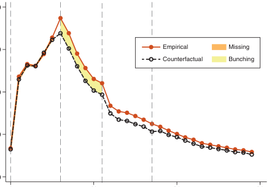

NOTE: figure/graphic rendered as an image from the PDF; its content is not machine-readable text. Caption (if any) follows as the next block.

**text found inside the figure**

Empirical

Counterfactual

Missing

Bunching

Page 14

*VOL. 15 NO. 1 305 VAN DOORNIK ET AL.: STRATEGIC FORMAL LAYOFFS*

In columns 3 to 5, we follow the methodology in Chetty, Friedman, and Saez (2013) by estimating excess layoff rates as the triple-difference in layoff rates for affected and unaffected workers around the six months eligibility threshold before and after the reform for each industry (column 3) and municipality (columns 4 and 5). We then correlate the resulting excess layoff rates with labor market informality. We find similar point estimates with a 0.12 and 0.11 percentage point greater decrease in layoff rates for affected workers with tenure of 6 to 11 months when they lose eligibility for UI benefits after the reform per 10 percentage point increase in labor market informality at the industry and municipality levels, respectively (columns 3 and 4). In column 5 we predict labor market informality at the municipality level based on a municipality’s industry composition and include the predicted informality level as a control variable. The estimate remains almost identical after including the predicted level of labor market informality, which suggests that geographical variation provides a distinct source of informality.<sup>9</sup> The consistency of the estimates across different sources of variation in labor market informality and estimation methods validates the interpretation of the results.

*Informal Employment*.—Next, we assess the extent to which higher layoff rates of workers who qualify for UI benefits are related to transitions to informal employment. Formal-to-formal transitions can be identified from administrative data. However, since informal employment is not recorded, administrative data do not allow us to distinguish between formal-to-informal employment transitions and formal-to-unemployment transitions.

The PME survey helps us overcome this obstacle. It includes information on formal employment, informal employment, and unemployment and can be transformed into a panel using the algorithm provided by Ribas and Soares (2008). This allows us

9 In Table A.3 in the online Appendix, we replicate the Chetty, Friedman, and Saez (2013) methodology for our bunching estimates and find qualitatively identical results.

Table 4—Bunching Estimation

[output not shown]

NOTE: table converted from PDF layout to HTML text; cell boundaries are reconstructed. See PDF if exact alignment matters.

*Notes:* This table reports bunching (*B* <sup>ˆ</sup> /*N* 6+ *pre* ) and missing mass (*M* ˆ /*N* 6+ *pre* ) of layoff rates above and below the six-month tenure threshold, respectively. The empirical distribution is estimated based on affected workers from March 2014 to February 2015. The counterfactual distribution is based on affected workers from March 2015 to February 2016 and adjusted based on the difference in pre-reform and postreform layoff rates of unaffected workers. Standard errors from bootstrapping 100 random samples with replacement are reported in parentheses.

Page 15

*306 AMERICAN ECONOMIC JOURNAL: APPLIED ECONOMICS JANUARY 2023*

to track individuals’ employment status over time. Specifically, we observe whether workers transition to unemployment or informal employment upon formal layoff.<sup>10</sup>

To formally assess whether higher layoff rates of workers who qualify for UI benefits are related to informal employment inflow, we estimate

(3) *Informa**l**it* = α*t*′ + β1 × 6*Month**s**it* + β2 × 6*Month**s**it* × *Refor**m**t* + ϵ*it*,

where *Informa**l**it* is a dummy variable that takes the value of one if worker *i* reports being informally employed following a month in which the worker reports being

10 The PME does not differentiate between layoffs and other forms of separations. However, our previous results suggest that the reform does not affect other forms of separations.

Table 5—Formal Layoffs and Labor Market Informality

[output not shown]

NOTE: table converted from PDF layout to HTML text; cell boundaries are reconstructed. See PDF if exact alignment matters.

*Notes:* The dependent variable *Layof**f**it* is a dummy variable that takes the value of one if worker *i* is formally laid off in month *t* and zero otherwise. The dependent variable *ExcessLayoff* is the triple-difference between changes in layoff rates for workers in the 6 to 11 months tenure range compared with the 0 to 5 months tenure range around the reform for affected relative to unaffected workers in a given industry (column 3) or municipality (columns 4 and 5). The dummy variable 6*Month**s**it* takes the value of one for workers with tenure of six to one months and zero for workers with tenure of up to five months. The dummy variable *Refor**m**t* takes the value of one for the postreform period from March 2015 to February 2016 and zero for the pre-reform period from March 2014 to February 2015. The dummy variable *Affecte**d**i* takes the value of one for workers with zero or one prior UI benefits spell and zero for workers with two or more prior UI spells. The variable *Informal* is the share of informal employment in a given industry (columns 1 and 3) or municipality (columns 2, 4, and 5). The variable <sup>ˆ</sup> *Informal* is the predicted level of informality at the municipality level based on its industry composition. Due to computation constraints, the estimates in columns 1 and 2 are based on a 10 percent random sample. Standard errors are reported in parentheses. The bottom part of the table provides information on fixed effects and the clustering of standard errors.

Page 16

*VOL. 15 NO. 1 307 VAN DOORNIK ET AL.: STRATEGIC FORMAL LAYOFFS*

formally employed and zero if the worker reports to be unemployed following a month in which the worker reports to be formally employed. The dummy variable  6*Month**s**it* takes the value of 1 for workers with tenure of 6 to 11 months in the last month of formal employment and 0 for workers with tenure of 4 to 5 months in the last month of formal employment. The dummy variable *Refor**m**t* takes the value of one for the postreform period from March to November 2015 and zero for the pre-reform period from May 2014 to January 2015.<sup>11</sup>

The results are displayed in Table 6, columns 1 to 3. We find similar results when we include month fixed effects (column 1), month and municipality fixed effects (column 2), or month-municipality fixed effects (column 3). Laid-off workers with tenure of 6 to 11 months become about 6 to 7 percentage points less likely to transition to informal employment following a formal layoff when they become ineligible for UI benefits after the reform. Since the PME survey does not allow us to differentiate between workers affected and workers unaffected by the reform, the magnitude of the effect on treated workers is about 1.5 times the estimated effect (about onethird of workers are unaffected by the reform).

To examine whether the rate of formal-to-formal transitions changes after the reform, we return to administrative data, which allows us to identify cases in which a worker is laid off by one firm and immediately takes on a formal job at a different firm. Specifically, we estimate equation (3) for the time period from March 2014 to February 2016 with *Forma**l**it* as the dependent variable, which is a dummy variable that takes the value of one if worker *i* is formally laid off in month *t* and formally employed at a different firm the next month and zero if worker *i* is laid off in month  *t* and not formally employed in the next month. The results are displayed in Table 6, column 4. After the reform the share of workers who transition to another formal job upon being laid off increases by 3.26 percentage points.

Together, the results from Table 6 allow us to compute the share of the additional layoffs due to eligibility for UI benefits that can be attributed to formal-to-formal employment transitions, transitions to informal employment, and transitions to unemployment. The results from Table 3, column 1 suggest that formal layoff rates are 11.11 percent higher when workers are eligible for UI benefits. In the data 20.5 percent of laid-off workers with a tenure of 6 to 11 months at layoff transition to formal employment after the reform. Before the reform a 3.26 percentage point lower rate of workers transition formal to formal. This suggests that the share of formal-to-formal transitions is similar before and after the reform ((20.50 − 3.26) × 1.1111 = 19.16 versus 20.50). This in turn implies that the additional workers laid off due to eligibility for UI benefits transition to either informal employment or unemployment.

Since the magnitude of the effect on treated workers is about 1.5 times the estimated effect, the average estimate across columns 1 to 3 of Table 6 implies that workers are (6.28 × 1.5) = 9.42 percentage points less likely to transition from formal

11 Since the PME is discontinued at the beginning of 2016, the last cohort of laid-off workers we include is November 2015. For individuals who are formally employed in February 2015 and no longer formally employed in March 2015, we do not know whether the layoff occurred in the pre-reform or postreform period. Thus, we do not assign February 2015 to either period.

Page 17

*308 AMERICAN ECONOMIC JOURNAL: APPLIED ECONOMICS JANUARY 2023*

to informal employment when they are no longer eligible for UI benefits. Thus, most (9.42 × 1.1111/11.11 = 94.16 percent) of the 11.11 percent of strategic layoffs estimated in Section IIB are related to informal employment, consistent with the fact that most of the additional layoffs occur in industries and municipalities with higher degrees of labor market informality.

C. *Recalls and Informal Employment at the Same Firm*

The evidence on layoff rates suggests that eligibility for UI benefits leads to additional layoffs that would not have occurred otherwise in the presence of informal labor markets. This is inconsistent with mechanisms related to shocks to the joint surplus of formal employment relationships, which would predict that discontinuity in eligibility rules leads to layoff delays rather than additional layoffs (Khoury 2021). In this section we assess the presence of recall patterns, hiring of workers to replace laid-off workers, and salary patterns consistent with coordination or collusion between workers and firms to extract rents from the UI system. It is important to note that this analysis does not preclude the existence of other mechanisms to extract rents from the UI system through strategic layoffs, e.g., shirking.

Firms and workers may devise various strategies to extract rents from the UI system while workers are employed informally. We focus on two possible strategies that provide empirical predictions, which we can test in the data. First, firms may temporarily lay off workers to allow them to receive UI benefits while they

Table 6—Informal Employment

[output not shown]

NOTE: table converted from PDF layout to HTML text; cell boundaries are reconstructed. See PDF if exact alignment matters.

*Notes:* The results in columns 1 to 3 are based on data from the PME survey; the results in column 4 are based on administrative data from RAIS. The dependent variable *Informa**l**it* takes the value of one if worker *i* reports to be informally employed following formal employment in month *t* and zero if worker *i* reports to be unemployed following formal employment in month *t*. The dependent variable *Forma**l**it* is a dummy variable that takes the value of one if worker *i* transitions to a different formal job upon layoff in month *t* and zero if worker *i* transitions to formal unemployment. The dummy variable 6*Month**s**it* takes the value of 1 for workers with tenure of 6 to 11 months and 0 for workers with tenure of up to 5 months (4 to 5 months in columns 1 to 3). The dummy variable *Refor**m**t* takes the value of one for the postreform period from March to November 2015 and zero for the pre-reform period from May 2014 to January 2015 in columns 1 to 3 and one for the postreform period from March 2015 to February 2016 and zero for the pre-reform period from March 2014 to February 2015 in column 4. Standard errors are reported in parentheses. The bottom part of the table provides information on fixed effects and the clustering of standard errors.

Page 18

*VOL. 15 NO. 1 309 VAN DOORNIK ET AL.: STRATEGIC FORMAL LAYOFFS*

work informally and recall them once their benefits payments cease. In this case we should see that firms are more likely to recall workers who are laid off when they become eligible for UI benefits. Second, a firm may keep a formally laid-off worker as an informal employee. While informal employment is not directly observable, we can indirectly proxy for keeping workers employed informally by examining differences in the rate at which firms replace a laid-off worker. Some layoffs are motivated by firms’ desire to replace a given worker with a more productive one. In the data we observe that for more than half of layoffs, firms hire a different worker within a month of laying off a worker. However, if firms continue to employ a formally laidoff worker informally, the firm does not need to replace the worker.

*Recalls*.—We start by exploring whether firms that lay off workers when they become eligible for UI benefits are more likely to recall them when their benefits cease. Specifically, for workers laid off with a tenure of 11 months or fewer, we estimate

(4) *Recal**l* *it* 4−10 = α*t*′ + α6*m*,*t* + α*ten*,*cal* + β1 × *Affecte**d**i* + β2 × 6*Month**s**it*

× *Affecte**d**i* + β3 × 6*Month**s**it* × *Refor**m**t* × *Affecte**d**i* + ϵ*it*,

where *Recal**l* *it* 4−10 is a dummy variable that takes the value of 1 if worker *i* returns to the same firm 4 to 10 months after being laid off and 0 otherwise. Since workers are eligible for at least three months of UI benefits, we start the recall window four months after layoff. We end the recall window 10 months after layoff, since workers may not apply for UI benefits within 16 months of their last successful application. Thus, firms that repeatedly lay off and recall the same worker have an incentive to recall workers up to ten months after layoff in order for them to be eligible for benefits after another six months of formal employment. The dummy variable 6*Month**s**it* takes the value of 1 for workers with tenure of 6 to 11 months at layoff and 0 for workers with tenure of up to 5 months at layoff. The dummy variable *Affecte**d**i* takes the value of one for workers with zero or one prior UI benefits spell at the time of the reform and zero otherwise. The dummy variable *Refor**m**t* takes the value of one for workers laid off between March 2015 and February 2016 and zero for workers laid off between March 2014 and February 2015. We control for municipality-industry-occupation-month fixed effects (α*t*′) to absorb shocks at the local industry-occupation level, eligibility-month fixed effects (α6*m*,*t*) to control for differences in recalls for workers on either side of the threshold unrelated to the reform, and tenure–calendar month fixed effects (α*ten*,*cal*) to control for tenure-specific seasonal patterns.

The results are displayed in Table 7, column 1. We find that strategically laidoff workers who are eligible for UI benefits are more likely to be recalled by their former employer when their benefits cease. After the reform, when workers with 6 to 11 months’ tenure at layoff are no longer eligible for UI benefits, they become 0.35 percentage points less likely to be recalled by their former employer, which is

Page 19

*310 AMERICAN ECONOMIC JOURNAL: APPLIED ECONOMICS JANUARY 2023*

equivalent to 9.56 percent greater recall rates for workers who are laid off after they become eligible for UI benefits. Thus, firms are not only more likely to lay off workers when they qualify for UI benefits but also more likely to recall these workers, consistent with formal unemployment spells being timed to coincide with workers’ eligibility for UI benefits.

*Worker Replacement*.—Next, we assess whether some workers who are laid off as they qualify for UI benefits remain informally employed by their previous employer. Since informal employment is not recorded in administrative data, we resort to indirect evidence. When firms lay off a worker, they often hire another worker as a replacement. If firms continue to employ a worker informally, a replacement is not required. Specifically, we estimate

(5) *Replac**e**i*,*t*+1 = α*t*′ + α6*m*,*t* + α*ten*,*cal* + β1 × *Affecte**d**i* + β2 × 6*Month**s**it*

× *Affecte**d**i* + β3 × 6*Month**s**it* × *Refor**m**t* × *Affecte**d**i* + ϵ*it*,

where *Replac**e**i*,*t*+1 is a dummy variable that takes the value of one if a firm hires a new worker within one month of laying off worker *i* in month *t* and zero otherwise. The dummy variable 6*Month**s**it* takes the value of 1 for workers with tenure of 6 to 11 months at layoff and 0 for workers with tenure of up to 5 months at layoff. We exclude months in which a firm lays off multiple workers. The dummy variable *Affecte**d**i* takes the value of one for workers with zero or one prior UI benefits spell at the time of the reform and zero otherwise. The dummy variable *Refor**m**t* takes the value of one for workers laid off between March 2015 and February 2016 and zero for workers laid off between March 2014 and February 2015. We control for municipality-industry-occupation-month fixed effects (α*t*′) to absorb shocks at the local industry-occupation level, eligibility-month fixed effects (α6*m*,*t*) to control for differences in replacement of workers on either side of the threshold unrelated to the reform, and tenure–calendar month fixed effects (α*ten*,*cal*) to control for tenure-specific seasonal patterns in worker replacement.

The results are displayed in Table 7, column 2. When workers with 6 to 11 months’ tenure lose eligibility for UI benefits after the reform, the difference in the rate of hiring a replacement worker increases by 0.72. This suggests that firms are less likely to replace workers laid off when they become eligible for UI benefits, consistent with some of them continuing to be informally employed by the firm.

*Salary*.—Finally, to assess whether workers and firms share rents from the UI system through salaries, we examine changes in salaries for affected and unaffected workers around the reform. Figure 6 depicts the time series evolution of salaries for affected relative to unaffected workers around the reform. While we observe parallel trends before the reform, salaries increase for affected workers following the announcement of the reform in December 2014 and continue to increase throughout 2015.

Page 20

*VOL. 15 NO. 1 311 VAN DOORNIK ET AL.: STRATEGIC FORMAL LAYOFFS*

In Table 8, we report the results from estimating

(6) log(*salary*)*it* = α*i* + α*jt* + α*t*′ + β2 × *Affecte**d**i* × *Refor**m**t* + ϵ*it*,

where log(*salary*)*it* is the log of worker *i*’s salary in month *t*. Since workers became aware of the implications of the reform once it was announced on December 29, 2014, we define the *Refor**m**t* dummy as one from January to December 2015 and as zero from January 2013 to December 2014. The dummy variable *Affecte**d**i* takes the value of one for workers affected by the reform and zero for workers unaffected by the reform. Worker fixed effects (α*i*) ensure that we track salaries for the same worker over time. As before, month-municipality-industry-occupation fixed effects (α*t*′) ensure that we compare salaries of affected and unaffected workers in the same municipality, industry, and occupation within a given month. Finally, we control for firm-month fixed effects (α*jt*) to ensure that changes in salaries are not driven by affected and unaffected workers being employed by different types of firms.

The results in column 1 show that salaries of workers affected by the reform increase by 0.80 percent relative to workers unaffected by the reform. In addition, salaries increase by 0.30 percent more for affected workers who were laid off with a tenure of 6 to 17 months in the year before the reform in column 2, which suggests that salary increases are greater for workers who engage in strategic layoffs to

Table 7—Recalls and Worker Replacement

Dependent variable: *Recal**l* *it* 4−10 *Replac**e**i*,*t*+1

Mean: (0.0366) (0.5831) (1) (2)

*Affecte**d**i* 0.0013 −0.0073 (0.0003) (0.0012) 6*Month**s**it* × *Affecte**d**i* −0.0035 0.0003 (0.0007) (0.0013) 6*Month**s**it* × *Refor**m**t* × *Affecte**d**i* −0.0035 0.0072 (0.0006) (0.0013)

Month × Municipality × Industry × Occupation FE Yes Yes Month × Eligibility FE Yes Yes Tenure × Calendar-Month FE Yes Yes Clustered SE Muni Muni

Observations 7,035,103 6,297,271 *R* <sup>2</sup> 0.305 0.292

*Notes:* The dependent variable *Recal**l* *it* 4−10 is a dummy variable that takes the value of one if worker *i* is recalled four to ten months after being laid off and zero otherwise. The dependent variable *Replac**e**i*,*t*+1 is a dummy variable that takes the value of one if a firm hires a new worker within one month of laying off worker *i*. The dummy variable 6*Month**s**it* takes the value of 1 for workers with tenure of 6 to 11 months and 0 for workers with tenure of up to 5 months. The dummy variable *Refor**m**t* takes the value of one from March 2015 to February 2016 and zero from March 2014 to February 2015. The dummy variable *Affecte**d**i* takes the value of one for workers with zero or one prior UI benefits spell and zero for workers with two or more prior UI spells. Standard errors are reported in parentheses. The bottom part of the table provides information on fixed effects and the clustering of standard errors.

Page 21

*312 AMERICAN ECONOMIC JOURNAL: APPLIED ECONOMICS JANUARY 2023*

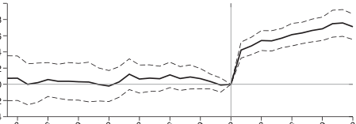

NOTE: figure/graphic rendered as an image from the PDF; its content is not machine-readable text. Caption (if any) follows as the next block.

extract rents from the UI system. Given that our previous results imply that 11.11 percent of layoffs in the tenure range from 6 to 11 months are strategic with respect to eligibility for UI benefits, the 0.30 percent increase in salaries is consistent with a (0.3/0.1111) = 2.7 percent increase in salaries for strategic workers. Together, the results suggest that workers whose layoff timing coincides with eligibility for UI benefits before the reform accept a lower salary, potentially as a means to share rents extracted from the UI system with their employer.

Table 8—Salaries

[output not shown]

NOTE: table converted from PDF layout to HTML text; cell boundaries are reconstructed. See PDF if exact alignment matters.

*Notes:* The dependent variable log(*salary*)*it* is the log of worker *i*’s salary in month *t*. The dummy variable *Affecte**d**i* takes the value of one for workers with zero or one prior UI benefits spell and zero for workers with two or more prior UI benefits spells. The dummy variable  *Refor**m**t* takes the value of one from January to December 2015 and zero from January 2013 to December 2014. The dummy variable *Strategi**c**i* takes the value of 1 if worker *i* was laid off with a tenure of 6 to 17 months during the pre-reform period and 0 otherwise. Due to computational constraints, the estimates are based on a 40 percent random sample. Standard errors are reported in parentheses. The bottom part of the table provides information on fixed effects and the clustering of standard errors.

Figure 6. Salaries

*Notes:* This figure plots the log difference in residualized salaries for affected and unaffected workers from January 2013 to December 2015 normalized to zero in December 2014, residualized by controlling for individual, industry-municipality-occupation-month, and firm-month fixed effects. Due to computational constraints, the estimates are based on a 40 percent random sample. The dashed lines represent 99 percent confidence intervals.

2013:3

2013:6

2013:9

2013:12

2014:3

2014:6

2014:9

2014:12

2015:3

2015:6

2015:9

2015:12

−0.004

−0.002

0

0.002

0.004

0.006

0.008

0.01

log(salary)

Page 22

*VOL. 15 NO. 1 313 VAN DOORNIK ET AL.: STRATEGIC FORMAL LAYOFFS*

#### **III. Costs of Strategic Unemployment to the UI System**

In this section we quantify the costs of strategic unemployment for the UI system. Our findings in Section IIB suggest that 11.11 percent of layoffs are driven by eligibility for UI benefits and 94.16 percent of the additional layoffs are related to workers transitioning to informal employment upon layoff. Rent extraction from the UI system generates a scheme of transfers to firms for which it is easier to game the system (Anderson and Meyer 1997a) and reduces the funds available for insurance purposes. The back-of-the-envelope estimates we provide should be interpreted as a rough approximation since we make several assumptions in their derivation.

We document that about 11.11 percent of layoffs above the 6-month threshold are due to workers’ eligibility for UI benefits (Table 3, columns 1 and 6). For tenure beyond 17 months, we need to make an assumption to compute the full costs of strategic formal unemployment to the system. We consider a conservative scenario, where we assume that strategic layoffs cease immediately above 17 months’ tenure, and an alternative scenario, where we assume that strategic layoffs persist at the same rate above 17 months’ tenure. This provides us with a range in which the actual costs are likely to fall. From the Ministry of Economics, we obtain data on the fraction of UI payments made to workers with a given level of tenure at layoff. In 2014 19.4 percent of UI benefits were paid to workers with tenure of no more than 17 months at layoff. Thus, under the conservative scenario 2.16 percent of all UI payments go to strategically formally unemployed workers (0.194 × 0.1111 = 2.16 percent). Under the alternative scenario 11.11 percent of unemployment payments go to strategically formally unemployed workers.

In 2014 total UI benefits payments were R$32.8 billion, or 0.6 percent of GDP. For the conservative scenario, 2.16 percent of the total UI benefits payments of R$32.8 billion equals R$0.71 billion, or 0.013 percent of GDP. The respective value for the alternative scenario is 0.067 percent of GDP. The annual costs and distortions from strategic formal unemployment increase with the size of informal labor markets. The estimates from Table 5 imply that strategic layoffs increase by about 0.11 percentage points per 10 percentage point increase in labor market informality at the industry or municipality level. We depict the degree of strategic formal layoffs in Figure 7 (solid line). Additionally, we add a plot of the range of total costs as a fraction of GDP for different levels of labor market informality for the conservative and alternative scenarios (dotted lines). For markets with very low levels of informality, costs to the UI system due to strategic formal unemployment are negligible. However, they can reach more than 0.03 percent of GDP for high levels of labor market informality even under the most conservative assumption and more than 0.15 percent of GDP under the least conservative assumption. Our cross-sectional estimates also allow us to relate our results to recent studies that examine differences in layoff rates around tenure and age thresholds that discontinuously alter workers’ eligibility for severance payments in Austria (Card, Chetty, and Weber 2007) or UI benefits duration in Germany (Schmieder, von Wachter, and Bender 2012). While labor market informality reaches 28.5 percent in Brazil, according to the European Social Survey (2014) informality rates are 1.4 percent in Austria and 2.9 percent in Germany. At these levels of labor market informality, our

Page 23

*314 AMERICAN ECONOMIC JOURNAL: APPLIED ECONOMICS JANUARY 2023*

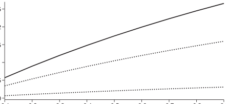

NOTE: figure/graphic rendered as an image from the PDF; its content is not machine-readable text. Caption (if any) follows as the next block.

estimates imply that the share of strategic layoffs due to eligibility for UI benefits is below 3 percent.<sup>12</sup>

Additional costs induced by strategic formal unemployment are harder to quantify. For example, it may lead workers to switch between the formal and the informal sector in a manner they would not deem optimal in the absence of UI benefits–induced unemployment (Haanwinckel and Soares forthcoming). Additionally, employing workers informally or having to replace workers temporarily may induce costs to firms and reduce investment in firm-specific human capital. Moreover, if strategic unemployment reduces the number of months for which workers are employed formally, the government’s tax revenues are lower.

#### **IV. Conclusion**

In recent years several mid-income and developing countries have begun implementing government-mandated unemployment insurance programs (Holzmann et al. 2011; ILO 2017). However, most of the empirical evidence on incentive effects of UI in the literature is from developed countries in North America and Europe. Understanding how labor market characteristics that are more prevalent in mid-income and developing countries interact with UI is important for the purpose of adapting the design of UI programs to these countries.

To assess incentive effects of UI in the presence of large informal labor markets, we exploit a reform of UI benefits eligibility criteria and cross-sectional variation in labor market informality in Brazil. We document that workers are 11.11 percent more likely to be laid off when they qualify for UI benefits. Formal layoffs and

12 In Card, Chetty, and Weber (2007), the incentives of workers and firms are also misaligned since workers would prefer to stay employed beyond the 36-month threshold to receive severance payments, whereas firms may prefer workers to be laid off before reaching the threshold to avoid severance payments. This misalignment of incentives may also contribute to the absence of strategic layoffs around the threshold.

Figure 7. Strategic Formal Unemployment Share by Informality

*Notes:* This figure depicts the fraction of formal layoffs due to eligibility for UI benefits (solid line) and the range of annual UI benefits payments due to strategic formal unemployment as a fraction of GDP (dotted lines) for different levels of labor market informality.

0.1 0.2 0.3 0.4 0.5 0.6 0.7 0.8 0.9 0

0.05

0.1

0.15

0.2

0.25

Informality

Strategic formal layoffs or

UI payments/GDP

Page 24

*VOL. 15 NO. 1 315 VAN DOORNIK ET AL.: STRATEGIC FORMAL LAYOFFS*

recalls are timed to coincide with eligibility for UI benefits. Specifically, firms lay off workers when they become eligible for UI benefits and recall them when their benefits cease. Changes in salaries around the reform indicate that workers pass on part of the rents they extract from the UI system to their employer, consistent with models of implicit contracting in the presence of UI (Feldstein 1976; Baily 1977; Christofides and McKenna 1996). Other mechanisms, such as shirking by workers or firms laying off workers who are less likely to find alternative employment in response to demand fluctuations, may also be relevant in contributing to layoffs due to eligibility for UI benefits.

Survey evidence suggests that the majority (94 percent) of the additional layoffs due to eligibility for UI benefits are related to transitions into informal employment and higher layoff rates of workers who qualify for UI are strongly correlated with labor market informality. This suggests that informal labor markets play an important role in strategic layoffs in response to UI eligibility. Moreover, firms are less likely to hire a replacement worker after laying off a worker who qualifies for UI benefits, compared with after laying off a worker who is ineligible for UI benefits. This suggests that some firms continue to employ workers informally while they are on UI benefits.

Our findings have implications for UI design. The timing of layoffs and recalls to match workers’ UI eligibility suggests that part of the UI system transfers rents toward firms and workers who exploit the system. While we are cautious about general welfare statements, our findings suggest that reducing potential rents could reduce the adverse incentive effects of UI in the presence of informal labor markets. Rents can be reduced by lowering replacement rates and the duration of benefits or by increasing experience rating to increase the cost of layoffs. More nuanced policy implications include tweaks to the UI system that prevent repeated temporary layoffs of the same worker by the same firm. The strong correlation with labor market informality suggests that these considerations are particularly important for mid-income and developing countries with large informal labor markets and that reducing labor market informality, or better monitoring in combination with higher fines, may also reduce adverse incentive effects.

REFERENCES

**Amarante, Verónica, Rodrigo Arim, and Andrés Dean.** 2013. “Unemployment Insurance Design and

Its Effects: Evidence for Uruguay.” *Desarrollo y Sociedad* 71: 7–42. **Anderson, Patricia M., and Bruce D. Meyer.** 1994. “The Effects of Unemployment Insurance Taxes

and Benefits on Layoffs Using Firm and Individual Data.” NBER Working Paper No. 4960. **Anderson, Patricia M., and Bruce D. Meyer.** 1997a. “The Effects of Firm Specific Taxes and Govern-

ment Mandates with an Application to the US Unemployment Insurance Program.” *Journal of Public Economics* 65 (2): 119–45. **Anderson, Patricia M., and Bruce D. Meyer.** 1997b. “Unemployment Insurance Take-Up Rates and the

After-Tax Value of Benefits.” *Quarterly Journal of Economics* 112 (3): 913–37. **Baily, Martin Neil.** 1977. “On the Theory of Layoffs and Unemployment.” *Econometrica* 45 (5):

1043–63. **Baker, Michael, and Samuel A. Rea.** 1998. “Employment Spells and Unemployment Insurance

Eligibility Requirements.” *Review of Economics and Statistics* 80 (1): 80–94. **Card, David, and Phillip B. Levine.** 1994. “Unemployment Insurance Taxes and the Cyclical and

Seasonal Properties of Unemployment.” *Journal of Public Economics* 53 (1): 1–29.

Page 25

*316 AMERICAN ECONOMIC JOURNAL: APPLIED ECONOMICS JANUARY 2023*

**Card, David, and Phillip B. Levine.** 2000. “Extended Benefits and the Duration of UI Spells: Evidence

from the New Jersey Extended Benefit Program.” *Journal of Public Economics* 78 (1): 107–38. **Card, David, Raj Chetty, and Andrea Weber.** 2007. “Cash-on-Hand and Competing Models of Inter-

temporal Behavior: New Evidence from the Labor Market.” *Quarterly Journal of Economics* 122 (4): 1511–60. **Card, David, Andrew Johnston, Pauline Leung, Alexandre Mas, and Zhuan Pei.** 2015. “The Effect of

Unemployment Benefits on the Duration of Unemployment Insurance Receipt: New Evidence from a Regression Kink Design in Missouri, 2003–2013.” *American Economic Review* 105 (5): 126–30. **Card, David, David S. Lee, Zhuan Pei, and Andrea Weber.** 2015. “Inference on Causal Effects in a

Generalized Regression Kink Design.” *Econometrica* 83 (6): 2453–83. **Carvalho, Cristiano C., Raphael Corbi, and Renata Narita.** 2018. “Unintended Consequences of

Unemployment Insurance: Evidence from Stricter Eligibility Criteria in Brazil.” *Economic Letters* 162: 157–61. **Chetty, Raj, John N. Friedman, and Emmanuel Saez.** 2013. “Using Differences in Knowledge across

Neighborhoods to Uncover the Impacts of the EITC on Earnings.” *American Economic Review* 103 (7): 2683–2721. **Chetty, Raj, John N. Friedman, Tore Olsen, and Luigi Pistaferri.** 2011. “Adjustment Costs, Firm

Responses, and Micro versus Macro Labor Supply Elasticities: Evidence from Danish Tax Records.” *Quarterly Journal of Economics* 126 (2): 749–804. **Christofides, Louis N., and C.J. McKenna.** 1995. “Unemployment Insurance and Moral Hazard in

Employment.” *Economic Letters* 49 (2): 205–10. **Christofides, L.N., and C.J. McKenna.** 1996. “Unemployment Insurance and Job Duration in Canada.”

*Journal of Labor Economics* 14 (2): 286–312. **Doornik, Bernardus Van, David Schoenherr, and Janis Skrastins.** 2023. “Replication data for: Strate-

gic Formal Layoffs: Unemployment Insurance and Informal Labor Markets.” American Economic Association [publisher], Inter-university Consortium for Political and Social Research [distributor]*.* https://doi.org/10.3886/E153522V1*.* **Doornik, Bernardus Ferdinandus Nazar Van, Dimas Mateus Fazio, David Schoenherr, and Janis**

**Skrastins.** 2020. “Unemployment Insurance as a Subsidy to Risky Firms.” BCB Working Paper No. 523. **European Social Survey.** 2014. “Data File Edition 2.2. NSD - Norwegian Centre for Research Data,

Norway Data Archive and Distributor of ESS Data for ESS ERIC.” European Social Survey. http://dx.doi.org/10.21338/NSD-ESS7-2014 (accessed September 11, 2021). **Farber, Henry S., Jesse Rothstein, and Robert G. Valletta.** 2015. “The Effect of Extended Unemploy-

ment Insurance Benefits: Evidence from the 2012–2013 Phase-Out.” *American Economic Review* 105 (5): 171–76. **Feldstein, Martin.** 1976. “Temporary Layoffs in the Theory of Unemployment.” *Journal of Political*

*Economy* 84 (5): 937–58. **Feldstein, Martin.** 1978. “The Effects of Unemployment Insurance on Temporary Layoff Unemploy-

ment.” *American Economic Review* 68 (5): 834–46. **Fujita, Shigeru, and Giuseppe Moscarini.** 2017. “Recall and Unemployment.” *American Economic*

*Review* 107 (12): 3875–3916. **Gasparini, Leonardo, Francisco Haimovich, and Sergio Olivieri.** 2009. “Labor Informality Bias of a

Poverty-Alleviation Program in Argentina.” *Journal of Applied Economics* 12 (2): 181–205. **Gerard, François, and Gustavo Gonzaga.** 2021. “Informal Labor and the Efficiency Cost of Social

Programs: Evidence from Unemployment Insurance in Brazil.” *American Economic Journal: Economic Policy* 13 (3): 167–206. **González-Rozada, Martín, Lucas Ronconi, and Hernán Ruffo.** 2011. “Protecting Workers against

Unemployment in Latin America and the Caribbean: Evidence from Argentina.” IDB Working Paper. **Green, David A., and W. Craig Riddell.** 1997. “Qualifying for Unemployment Insurance: An Empirical

Analysis.” *Economic Journal* 107 (440): 67–84. **Green, David A., and Timothy C. Sargent.** 1998. “Unemployment Insurance and Job Durations: Sea-

sonal and Non-seasonal Jobs.” *Canadian Journal of Economics* 31 (2): 247–78. **Haanwinckel, Daniel, and Rodrigo R. Soares.** 2021. “Workforce Composition, Productivity, and

Labour Regulations in a Compensating Differentials Theory of Informality.” *Review of Economic Studies* 88 (6): 2970–3010. **Holzmann, Robert, Yann Pouget, Milan Vodopivec, and Michael Weber.** 2011. “Severance Pay Pro-

grams Around the World: History, Rationale, Status, and Reforms.” IZA Working Paper No. 5731.

Page 26

*VOL. 15 NO. 1 317 VAN DOORNIK ET AL.: STRATEGIC FORMAL LAYOFFS*

**IBGE.** 2010. “Censo Demográfico 2010, Tabela 3586.” IBGE. https://sidra.ibge.gov.br/tabela/3586

(accessed August, 8, 2021). **IBGE.** 2016. “Pesquisa Mensal de Emprego.” IBGE. https://ftp.ibge.gov.br/Trabalho_e_Rendimento/

Pesquisa_Mensal_de_Emprego/Microdados (accessed August 31, 2021). **IBGE.** 2020. “Classificaçõs Nacional de Atividades Econômicas.” IBGE. https://concla.ibge.gov.br/

busca-online-cnae.html?view=estrutura (accessed August 31, 2021). **IBGE.** 2021. “Índice Nacional de Preços ao Consumidor Amplo, Tabela 1737.” IBGE. https://sidra.

ibge.gov.br/tabela/1737 (accessed August 31, 2021). **ILO.** 2017. *World Social Protection Report 2017–19*. Geneva: ILO Publications. **Johnston, Andrew C., and Alexandre Mas.** 2018. “Potential Unemployment Insurance Duration and

Labor Supply: The Individual and Market-Level Response to a Benefit Cut.” *Journal of Political Economy* 126 (6): 2480–2522. **Jurajda, Štepán.** 2002. “Estimating the Effect of Unemployment Insurance Compensation on the

Labor Market Histories of Displaced Workers.” *Journal of Econometrics* 108 (2): 227–52. **Katz, Lawrence F.** 1986. “Layoffs, Recall, and the Duration of Unemployment.” NBER Working Paper

No. 1825. **Katz, Lawrence F., and Bruce D. Meyer.** 1990a. “The Impact of the Potential Duration of Unemploy-

ment Benefits on the Duration of Unemployment.” *Journal of Public Economics* 41 (1): 45–72. **Katz, Lawrence F., and Bruce D. Meyer.** 1990b. “Unemployment Insurance, Recall Expectations, and

Unemployment Outcomes.” *Quarterly Journal of Economics* 105 (4): 973–1002. **Khoury, Laura.** 2021. “Unemployment Benefits and the Timing of Layoffs.” Unpublished. **Kleven, Henrik J., and Mazhar Waseem.** 2013. “Using Notches to Uncover Optimization Frictions and

Structural Elasticities: Theory and Evidence from Pakistan.” *Quarterly Journal of Economics* 128 (2): 669–723. **Lalive, Rafael.** 2008. “How Do Extended Benefits Affect Unemployment Duration? A Regression Dis-

continuity Design.” *Journal of Econometrics* 142 (2): 785–806. **Landais, Camille.** 2015. “Assessing the Welfare Effects of Unemployment Benefits Using the Regres-

sion Kink Design.” *American Economic Journal: Economic Policy* 7 (4): 243–78. **Meyer, Bruce D.** 1990. “Unemployment Insurance and Unemployment Spells.” *Econometrica* 58 (4):

757–82. **Meyer, Bruce D.** 1995. “Lessons from the US Employment Insurance Experiments.” *Journal of Eco-*

*nomic Literature* 33 (1): 91–131. **Meyer, Bruce D., and Wallace K.C. Mok.** 2007. “Quasi-experimental Evidence on the Effects of Unem-

ployment Insurance from New York State.” NBER Working Paper No. 12865. **Ministério da Economia.** 2014–2016. “Relação Anual de Informaço¯µes Sociais.” Banco Central do

Brasil (accessed November 10, 2021). **Ministério do Trabalho.** 2016. “Base de Gestão do Seguro Desemprego.” Banco Central do Brasil

(accessed October 11, 2021). **Moffitt, Robert.** 1985. “Unemployment Insurance and the Distribution of Unemployment Spells.”

*Journal of Econometrics* 28 (1): 85–101. **Nekoei, Arash, and Andrea Weber.** 2015. “Recall Expectations and Duration Dependence.” *American*

*Economic Review Papers and Proceedings* 105 (5): 142–46. **Receita Federal do Brasil.** 2021a. “Cadastro de Pessoas Físicas.” Banco Central do Brasil (accessed

October 11, 2021). **Receita Federal do Brasil.** 2021b. “Cadastro Nacional da Pessoa Jurídica.” Banco Central do Brasil

(accessed October 11, 2021). **Ribas, Rafael Perez, and Sergei Suarez Dillon Soares.** 2008. “Sobre o Painel da Pesquisa Mensal de

Emprego (PME) do IBGE.” IPEA Discussion Paper 1348. **Rothstein, Jesse, and Robert G. Valletta.** 2017. “Scraping By: Income and Program Participation

after the Loss of Extended Unemployment Benefits.” *Journal of Policy Analysis and Management* 36 (4): 880–908. **Schmieder, Johannes F., Till von Wachter, and Stefan Bender.** 2012. “The Effects of Extended Unem-

ployment Insurance over the Business Cycle: Evidence from Regression Discontinuity Estimates Over 20 Years.” *Quarterly Journal of Economics* 127 (2): 701–52. **Schmieder, Johannes F., Till von Wachter, and Stefan Bender.** 2016. “The Effect of Unemployment

Benefits and Nonemployment Duration on Wages.” *American Economic Review* 106 (3): 739–77. **Solon, Gary.** 1979. “Labor Supply Effects of Extended Unemployment Benefits.” *Journal of Human*

*Resources* 14 (2): 247–55.

Page 27

*318 AMERICAN ECONOMIC JOURNAL: APPLIED ECONOMICS JANUARY 2023*

**Topel, Robert H.** 1983. “On Layoffs and Unemployment Insurance.” *American Economic Review*

73 (4): 541–59. **Topel, Robert H.** 1985. “Unemployment and Unemployment Insurance.” *Research in Labor Econom-*

*ics* 7: 91–135. **Winter-Ebmer, Rudolf.** 2003. “Benefit Duration and Unemployment Entry: A Quasi-experiment in

Austria.” *European Economic Review* 47 (2): 259–73.

Page 28

#### **This article has been cited by:**

1. Laura Khoury. 202⒊ Unemployment benefits and redundancies: Incidence and timing effects. *Journal of Public Economics* **226**, 10498⒋ [Crossref] 2. Mark Duggan, Audrey Guo, Andrew C. Johnston. 202⒊ Experience Rating as an Automatic Stabilizer. *Tax Policy and the Economy* **37**, 109-13⒊ [Crossref]